# 计数DP

Author: MiracleEEEE

From: ZJU CKC

# [Scoi2010]字符串

lxhgww最近接到了一个生成字符串的任务，任务需要他把n个1和m个0组成字符串，但是任务还要求在组成的字符串中，在任意的前k个字符中，1的个数不能少于0的个数。现在lxhgww想要知道满足要求的字符串共有多少个。$n,m\leq 10^6$

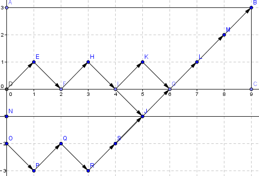

$$C(n + m, m) - C(n + m, m - 1)$$

# 51nod 1829 函数

想知道f:A->B这个函数（其中|A|=n, |B|=m）的所有映射关系要使B的每个元素都要被A的一个元素覆盖到。 数字可能很大你只要输出方案数模1,000,000,007即可。$n,m\leq 10^6$

- 先把问题转化一下，n个不同球放到m个相同盒子中，且任意一个盒子都不为空，那么这显然是个第二类斯特林数S(n,m)
- $ans=m!\times S(n,m)$

$$ S(n,m)=\frac{1}{m!}∑(-1)^i\times \binom{m}{i}\times(m-i)^n $$

# 51nod 1805 小树

问n个点有m个叶子的带标号无根树数量。$n,m\leq1000000$

一个节点是叶子当且仅当其在prufer序列中没有出现。那么答案就是$\binom{n}{m}\times F(n−m)$，其中$F(k)$表示有多少长度为$n-2$的序列满足这里面恰好出现了$k$种元素。

$$ F(k)=k!\times S(n-2,k) $$

# [CQOI2007] 余数之和sum

给出正整数n和k，计算j(n, k)=k mod 1 + k mod 2 + k mod 3 + … + k mod n的值，其中k mod i表示k除以i的余数。例如j(5, 3)=3 mod 1 + 3 mod 2 + 3 mod 3 + 3 mod 4 + 3 mod 5=0+1+0+3+3=7 $n,k\leq 10^9$

$$x \bmod i = x – (x / i) \times i$$

- $\left[\frac{x}{i}\right]$只有$O(\sqrt{x})$种取值
- 等差数列求和

# LOJ 6089

小Y有一个大小为$n$的背包，并且小Y有$n$种物品。

对于第$i$种物品，共有$i$个可以使用，并且对于每一个$i$物品，体积均为$i$。

求小Y把该背包装满的方案数为多少，答案对于$23333333$取模。

定义两种不同的方案为：当且仅当至少存在一种物品的使用数量不同。 $n\leq 10^5$

分成两类：

- $i\leq \sqrt{n}$

  单调队列优化多重背包$O(n\sqrt{n})$
- $i>\sqrt{n}$
  - 每个物体都不存在数量限制
  - 但是直接做完全背包的复杂度是$O(n^2)$的
  - 选择物体的数量不会超过$\sqrt{n}$，考虑整数划分
  - $g[i][j]$表示选了$i$个物体，总和为$j$，每次转移可以考虑加一个$\sqrt{n}$或者给所有数字都$+1$

# LOJ 2264. 「CTSC2017」吉夫特

输入一个长度为$n$的数列$a_1,a_2,\cdots,a_n$，问有多少个长度大于等于$2$的不上升的子序列满足 $$ \prod_{i=1}^k \binom{a_{b_{i-1}}}{a_{b_i}} \mod 2 > 0 $$

$n\leq 211985$，保证$a_i\leq 233333$两两不同

卢卡斯定理

$$ \binom{n}{m}=\binom{n/2}{m/2}\times\binom{n \bmod 2}{m\bmod 2} $$

那么整个组合数为$0$当且仅当存在两个相邻的数使得它们的二进位表示出现$0,1$这样的组合

- 如果$m \subseteq n$，那么$\binom{n}{m}=1$
- 后一个数是前一个数的子集
- 用$f[i]$表示以$i$结尾的序列数，倒过来做，枚举子集转移
- 复杂度$O(3^{\log 233333})$

# 51nod 1610

路径上所有边权的最大公约数定义为路径的值。

给定一个有向无环图$n\leq 100$个点，$m\leq 50000$条边

$T\leq 500$次修改，要求每次修改后求出多少条路径值为$1$

保证任何时刻图中的边权不超过$100$

答案可以容斥

$$ ans=\sum_{i=1}^k \mu(i)f(i) $$

$f(i)$表示值为$i$的倍数的路径条数，关键在维护$f(i)$

考虑对于一个特定的$k$，取出图中所有边权为$k$的倍数的边做DP

$$ dp[i][j][k]=\sum dp[l][j][k] $$

其中$i$到$l$有一条边权为$k$的倍数的边

修改后重新DP

# 51Nod 1835

给定$n$个点的无向图，问移除一些边后剩余$m$个连通块的方案数

$n,m\leq 500$

$dp[i][j]$表示$i$个点组成$j$个连通块的方案数

考虑第$i$个点所在的连通块大小

$$ f[i][j]=\sum_k \binom{i-1}{k-1}f[k][1]f[i-k][j-1] $$$$ f[i][1]=2^{i(i-1)/2}-\sum_k f[i][k] $$